# BANA 7025 - Data Wrangling Project

##### Hypothesis 6

**The customers who are part of a family are more likely to book FB(Full-board) meals**

Usually when families visit hotels, it is believed that would book entire meals(i.e. is Full - Board Meals) because of the kids with them. We’ll plot and calculate for the same.

```r
hotels %>% filter(is_family == TRUE) %>%
  summarise(Yes_FullBoard = sum(meal == "FB"),NO_FullBoard = sum(meal != "FB"))
```

```
##   Yes_FullBoard NO_FullBoard
## 1            84         9025
```

Plot for this

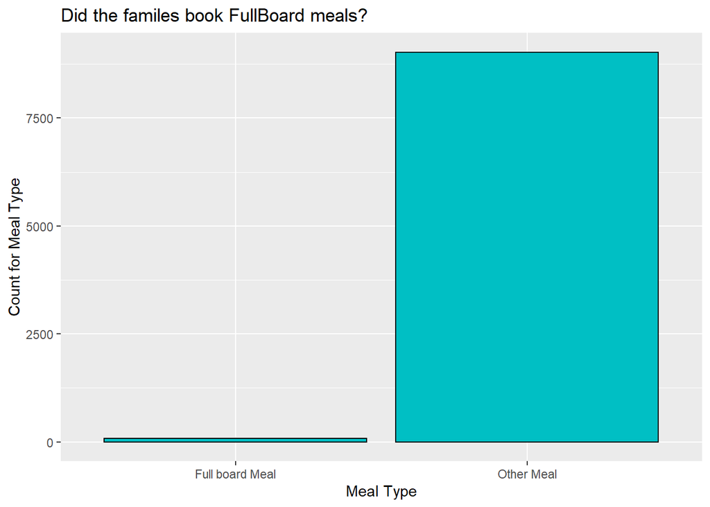

```r
hotels$is_fullboard <- (hotels$meal == "FB")
hotels$is_fullboard[hotels$is_fullboard == TRUE] <- "Full board Meal"
hotels$is_fullboard[hotels$is_fullboard == FALSE] <- "Other Meal"

hotels %>% filter(is_family == TRUE) %>%  ggplot(aes(is_fullboard))+
            geom_bar(col="black", fill="#00BFC4")+
            ggtitle("Did the familes book FullBoard meals?") +
            xlab("Meal Type") +
            ylab("Count for Meal Type")
```

Contrary to the hypothesis, it can be observed that families do not prefer Fullboard meals. There could be several reasons for it like as they are visit along with the family members, the families would like to tour the place and not stay at the hotel so booking all day meal would make little sense. Other reason could be the food at the hotel may be expensive.

##### Hypothesis 7

**Customers who do not belong to Portugal are likely to stay in weekends**

Since the hotels both city and resort are located in Portugal and people who’ll visit Portugal from outside the country are most likely to come for longer trip and at a time when the customers also have holidays i.e. either festive holidays or weekends. We aim to prove that customers who visit Portugal are more likely to stay at weekends because of the days off on weekends.

```r
hotels %>% filter(country != "PRT") %>%
  summarise(Yes_Weekend_Stay = sum(stays_in_weekend_nights > 0),NO_Weekend_Stay = sum(stays_in_weekend_nights == 0))
```

```
##   Yes_Weekend_Stay NO_Weekend_Stay
## 1            44653           26147
```

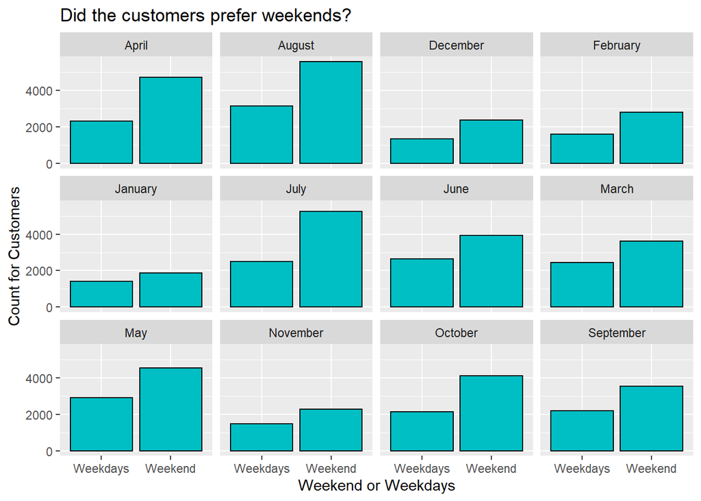

```r
hotels$is_weekend <- (hotels$stays_in_weekend_nights > 0)
hotels$is_weekend[hotels$is_weekend == TRUE] <- "Weekend"
hotels$is_weekend[hotels$is_weekend == FALSE] <- "Weekdays"

hotels %>% filter(country != "PRT") %>%
  ggplot(aes(is_weekend))+
            geom_bar(col="black", fill="#00BFC4")+
            facet_wrap(~arrival_date_month)+
            ggtitle("Did the customers prefer weekends?") +
            xlab("Weekend or Weekdays") +
            ylab("Count for Customers")
```

##### Hypothesis 8

**Resort hotels is likely to have more booking for weekend for customers from Portugal**

Given that the data is about hotels, one would think that since weekends are holidays people would tend to visit more on weekends. We try to prove our hypothesis by taking the count for each(Both weekdays and weekends).

```r
hotels %>% filter(country == "PRT") %>%
  summarise(Yes_Weekend_Stay = sum(stays_in_weekend_nights > 0),NO_Weekend_Stay = sum(stays_in_weekend_nights == 0))
```

```
##   Yes_Weekend_Stay NO_Weekend_Stay
## 1            22739           25851
```

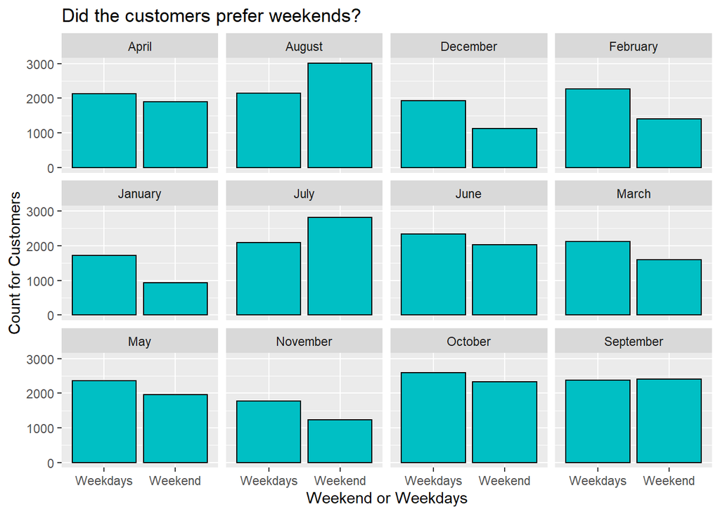

```r
hotels %>% filter(country == "PRT") %>%
  ggplot(aes(is_weekend))+
            geom_bar(col="black", fill="#00BFC4")+
            facet_wrap(~arrival_date_month)+
            ggtitle("Did the customers prefer weekends?") +
            xlab("Weekend or Weekdays") +
            ylab("Count for Customers")
```

##### Hypothesis 9

**Visitors with babies tend to book HB(Half Board) meals**

HB(Half Board) meal includes dinner so it is intuitive the families who are travelling with babies would be willing to meal plans that include dinner as they will most likely return to hotel at night.

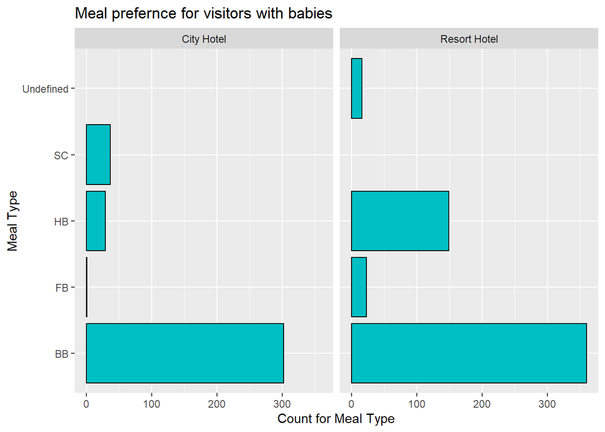

```r
hotels %>% filter(babies > 0 ) %>%
  ggplot(aes(meal))+
  geom_bar(col="black", fill="#00BFC4")+
  facet_wrap(~hotel)+
  coord_flip()+
  ggtitle("Meal prefernce for visitors with babies") +
            xlab("Meal Type") +
            ylab("Count for Meal Type")
```

As per the plot, it can be observed that visitors with babies largely prefers only breakfast meal plans, which is the same for every category. but a significant no. of visitors with babies also prefer HB meal plan.

### 4.4 Booking Profile Features

#### 4.4.1 Hypothesis Proposed

The booking profile of the customer in consonance with the other feature types can be used to derive holistic insights from the data. Following hypothesis will be tested:

- There is a relation between the distribution channel and ability of the hotel to provide the requested room
- Hotels in the city have greater traffic and are more susceptible to overbooking
- There is a significant relation between the room types and the adr
- There is a significant relation between the market segment and the assigned room types
- There is a significant relation between the distribution channel and the reserved room types
- Certain room types can have a larger lead time
- Larger lead time can lead to larger number of booking changes

We create a new variable that tracks the ability of the hotel to fulfil the booking by assiging the reserved room to its customer.

```r
hotels$same_room <- (hotels$reserved_room_type == hotels$assigned_room_type)
```

#### 4.4.2 Analysis and Trends to Answer Key Questions

We can now visually inspect the data to test the validity of our hypothesis.

##### Hypothesis 1

**Larger lead time can lead to larger number of booking changes**

To test and visualize the relationship between the booking changes and the lead time we use the following plot. Here we can see that there are a greater number of changes in bookings that were booked closer to the arrival date.

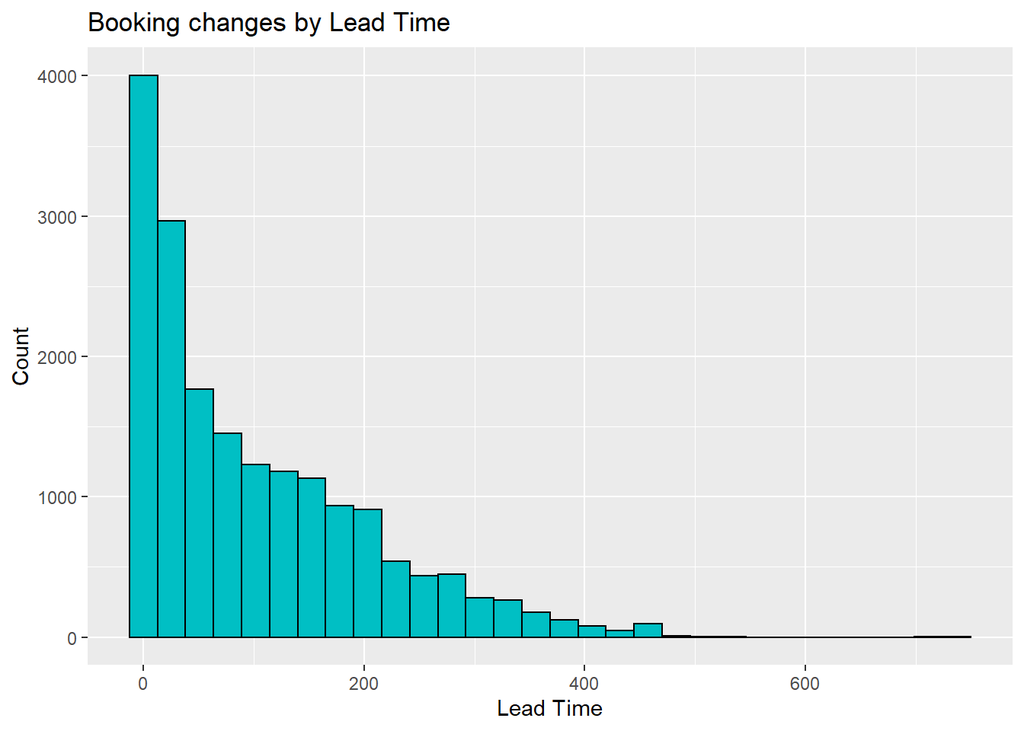

```r
hotels %>%
  filter(booking_changes > 0) %>%
    ggplot(aes(lead_time)) +
      geom_histogram(col = "black", fill="#00BFC4") +
        labs(title="Booking changes by Lead Time", x="Lead Time", y="Count")
```

##### Hypothesis 2

**There is a significant relation between the room types and the adr**

To test the validity of our hypothesis we will use the following plot:

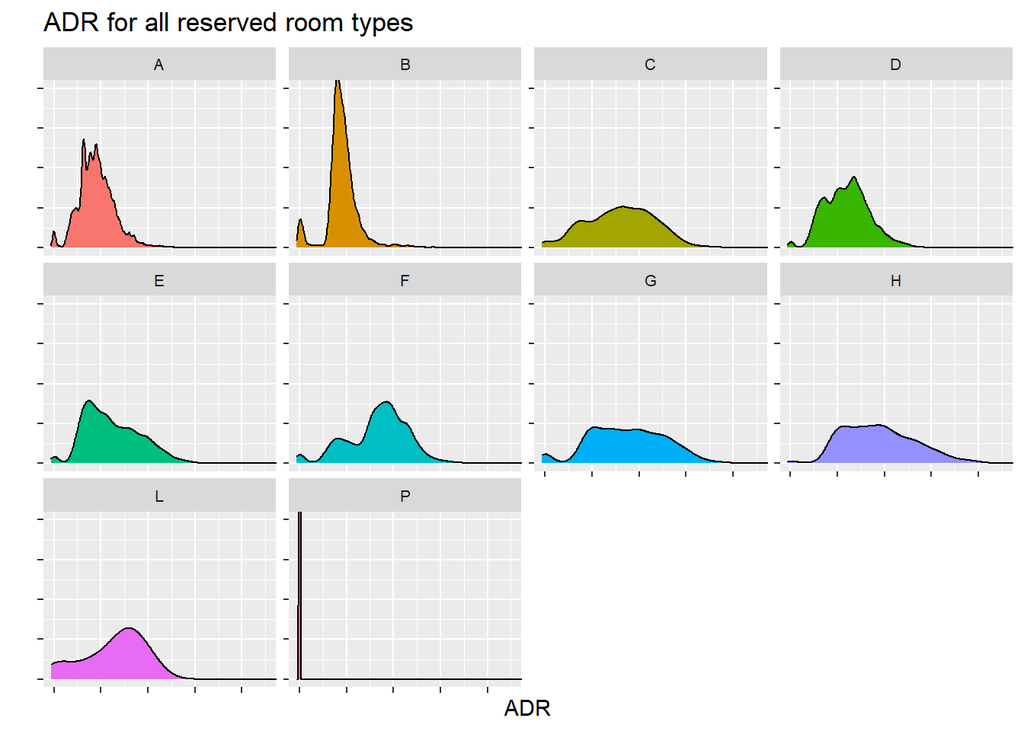

```r
library(hrbrthemes)
ggplot(data=hotels, aes(x=adr, group=reserved_room_type, fill=reserved_room_type)) +
    geom_density() +
  coord_cartesian(xlim = c(0,450),ylim = c(0,0.02)) +
  facet_wrap(~reserved_room_type,scale="free_y") +
  ggtitle("ADR for all reserved room types") +
  theme(legend.position="none",
        panel.spacing = unit(0.25, "lines"),
      strip.text.x = element_text(size = 8),
      axis.text.x=element_blank(),axis.text.y=element_blank()) +
  xlab("ADR") + ylab("")
```

The plot above helps understand the distribution of ADR for each room. A peak to the right would indicate a higher ADR on average and a flatter spread would indicate that the ADR is spread out. from this particular plot we can infer that rooms types - A, B, E and, P have on average lower ADR than the other rooms that seem to have a much flatter and wider distribution. Interestingly, room type P has almost a bar which would indicate 0 to low ADR.

##### Hypothesis 3

**There is a relation between the distribution channel and ability of the hotel to provide the requested room**

The distribution channel can affect the ability of a hotel to provide the same room to a customer. To test the validity of our hypothesis we will use the following plot:

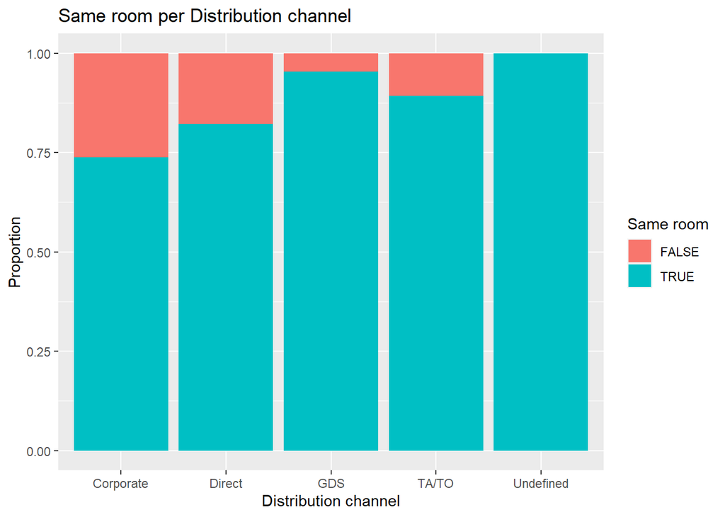

```r
ggplot(data = hotels, aes(distribution_channel, fill = factor(same_room))) +
  geom_bar(position = "fill") +
  labs(fill = "Same room") +
  xlab("Distribution channel") +
  ylab("Proportion") +
  ggtitle("Same room per Distribution channel")
```

The plot above does show a small trend i.e. GDS > TA/TO > Direct > Corporate in the ability to provide the same room. To further investigate this relationship we will see if any one hotel type is causing this trend.

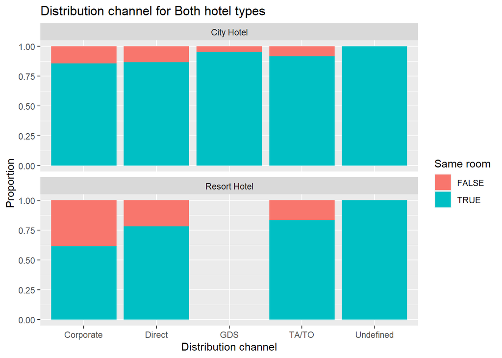

```r
ggplot(data = hotels, aes(distribution_channel, fill = factor(same_room))) +
  geom_bar(position = "fill") +
  labs(fill = "Same room") +
  xlab("Distribution channel") +
  ylab("Proportion") +
  ggtitle("Distribution channel for Both hotel types") +
  facet_wrap(~hotel, nrow = 2)
```

The plot above shows that trend is independent of the hotel type as the same can be observed here.

##### Hypothesis 4

**Hotels in the city have greater traffic and are more susceptible to overbooking**

The ability of a hotel to provide the reserved room to the customer is essential in customer satisfaction. However, there are times when a hotel is unable to provide the same. Here we want to visualize the relation between overbooking and the location or type of the hotel and the number of bookings. To test the validity of our hypothesis we will use the following plot:

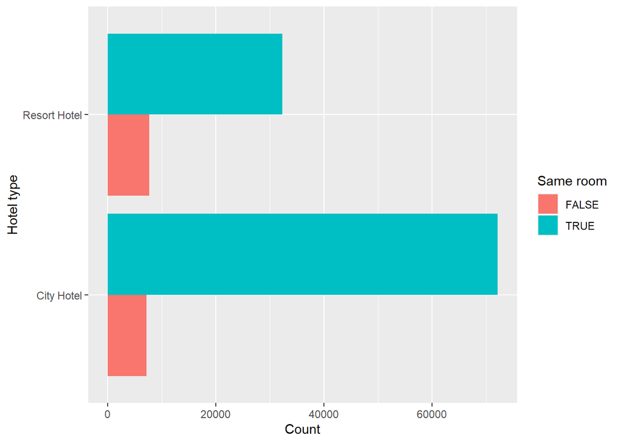

```r
ggplot(data = hotels, aes(hotel, fill = factor(same_room))) +
  geom_bar(position = "dodge") +
  labs(fill = "Same room") +
  coord_flip() +
  xlab("Hotel type") +
  ylab("Count")
```

```r
  ggtitle("Hotel types and overbooking")
```

```
## $title
## [1] "Hotel types and overbooking"
##
## attr(,"class")
## [1] "labels"
```

Here we can see that `City Hotels` do in fact have greater foot traffic but contrary to our initial hypothesis we see that `Resort Hotels`, despite having less than half the number of bookings have the same if not more changes to the room type which can be associated to overbooking. Thus, the location and the type of the hotel do play a role in the ability of a hotel in providing the same room to a customer.

##### Hypothesis 5

**There is a significant relation between the market segment and the assigned room types**

There may be a relation between market segment and the reserved room types, the reason for this relation may be intrinsic or extrinsic to the room type. To test the validity of our hypothesis we will use the following plot:

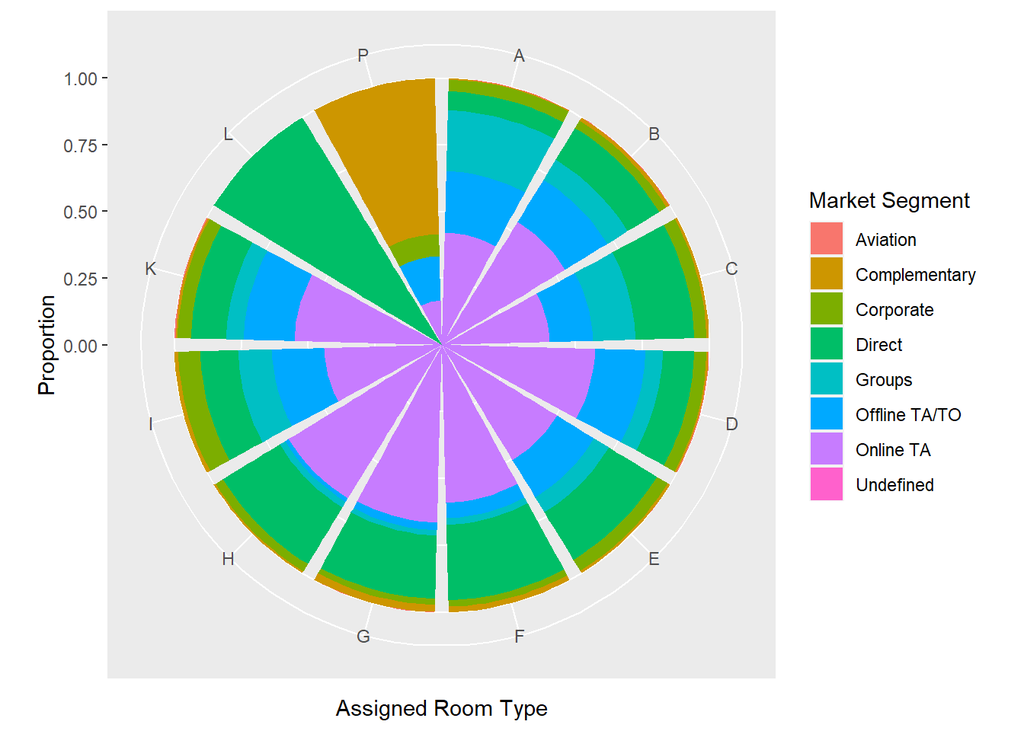

```r
ggplot(data = hotels, aes(assigned_room_type, fill = factor(market_segment))) +
  geom_bar(position = "fill") +
  coord_polar() +
  xlab("Assigned Room Type") +
  ylab("Proportion")+
  labs(fill = "Market Segment")
```

The plot above shows that only room types L and P are dominated by a single market segment and there is no relation for all other rooms to any single market segment.

##### Hypothesis 6

**There is a significant relation between the distribution channel and the reserved room types**

There may be a relation between distribution channel and the reserved room types, the reason for this relation may be intrinsic or extrinsic to the room type. To test the validity of our hypothesis we will use the following plot:

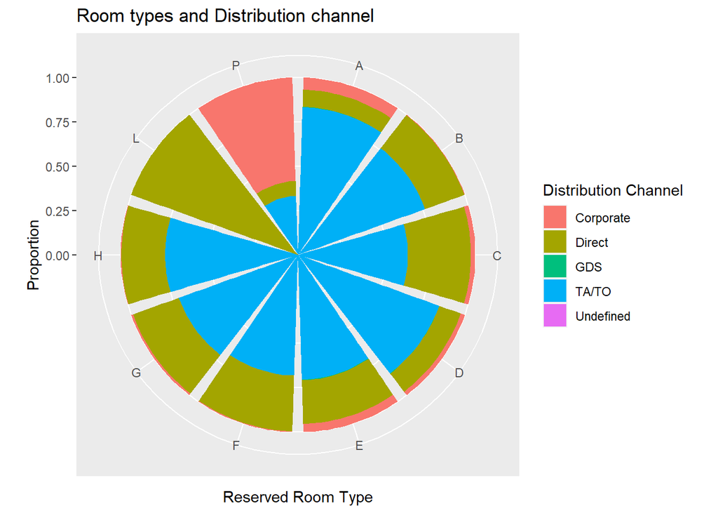

```r
ggplot(data = hotels, aes(reserved_room_type, fill = factor(distribution_channel))) +
  geom_bar(position = "fill") +
  coord_polar() +
  xlab("Reserved Room Type") +
  ylab("Proportion")+
  labs(fill = "Distribution Channel")+
  ggtitle("Room types and Distribution channel")
```

Rooms A, D, L and P are dominated by one distribution channel. Room L and P are for Direct and Corporate customers predominantly. This is in line with the plot above as room P was mostly complementary. In line with the above hypothesis we can conclude that there is no significant relation for all other rooms to any single market segment.

##### Hypothesis 7

**Certain room types can have a larger lead time**

To test the validity of our hypothesis we will use the following plot:

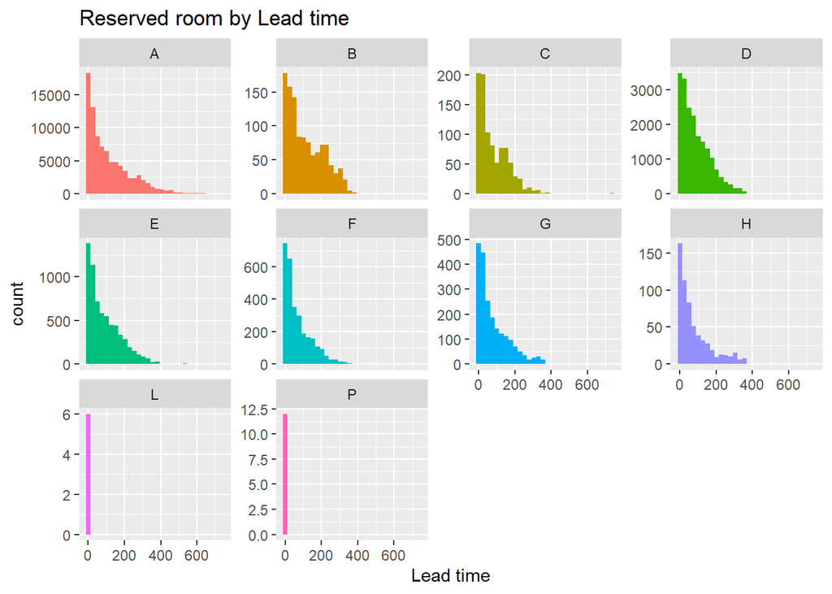

```r
ggplot(hotels, aes(lead_time,fill=reserved_room_type)) +
  geom_histogram() +
    labs(title="Reserved room by Lead time",
         x="Lead time")  +
  facet_wrap(~reserved_room_type, scale="free_y") +
  theme(legend.position="none")
```

The plot above in consonance from the plots above as we see room types L and P have the lowest lead time as they are either for only direct customer or complementary. We also see Rooms A and D are the most popular with lower lead times on average. Room B and C have a flatter spread here and when seen in consonance with their ADR distribution we can see that these rooms while relatively consistent on the ADR are on the lower side with higher lead times. Room L which caters to direct customers has the Lead time and ADR distribution.

### 4.5 Market Channel Features

#### 4.5.1 Hypothesis Proposed

The market channel metrics conveys the booking channel that was used by the customers for making the reservation. Our market channel metrics contain - Agent, Company, Distribution Channel and Market Segment. Based on our initial exploration we put forward the following hypothesis to gauge the impact of the booking channel on customer bookings:

- The bookings made through travel agencies tend to not get cancelled
- People with more family members tend to make bookings with travel agencies

On a overall level we see that customers prefer to make reservations through *online travel agencies* as we can see in the below plots for both `city Hotel` and `Resort Hotel`.

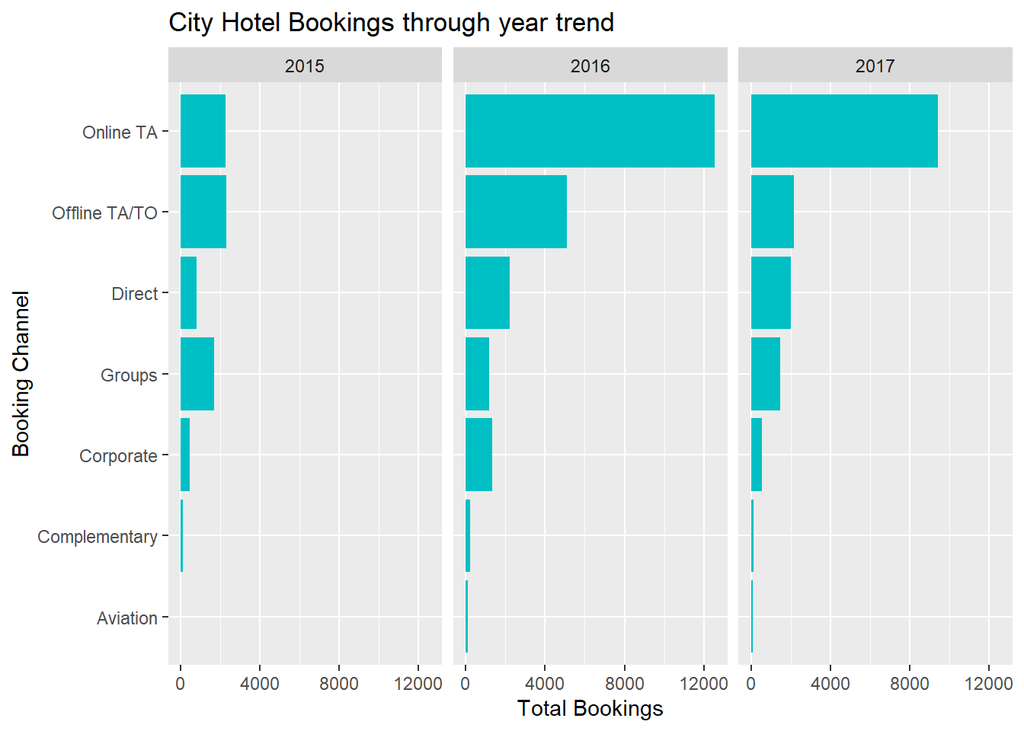

```r
hotel_mkseg <- hotels %>% select(hotel, arrival_date_year, market_segment, is_canceled) %>% filter(is_canceled == 0, ) %>%
              group_by(hotel, arrival_date_year, market_segment) %>% summarise(bookings = n())

ggplot(data = hotel_mkseg[hotel_mkseg$hotel == "City Hotel",], aes(x = reorder(market_segment, bookings), y = bookings)) +
  geom_bar(stat = "identity", fill = "#00BFC4") +
  coord_flip() +
  scale_y_continuous(name="Total Bookings") +
  scale_x_discrete(name="Booking Channel") +
  ggtitle("City Hotel Bookings through year trend") +
  facet_wrap(~arrival_date_year)
```

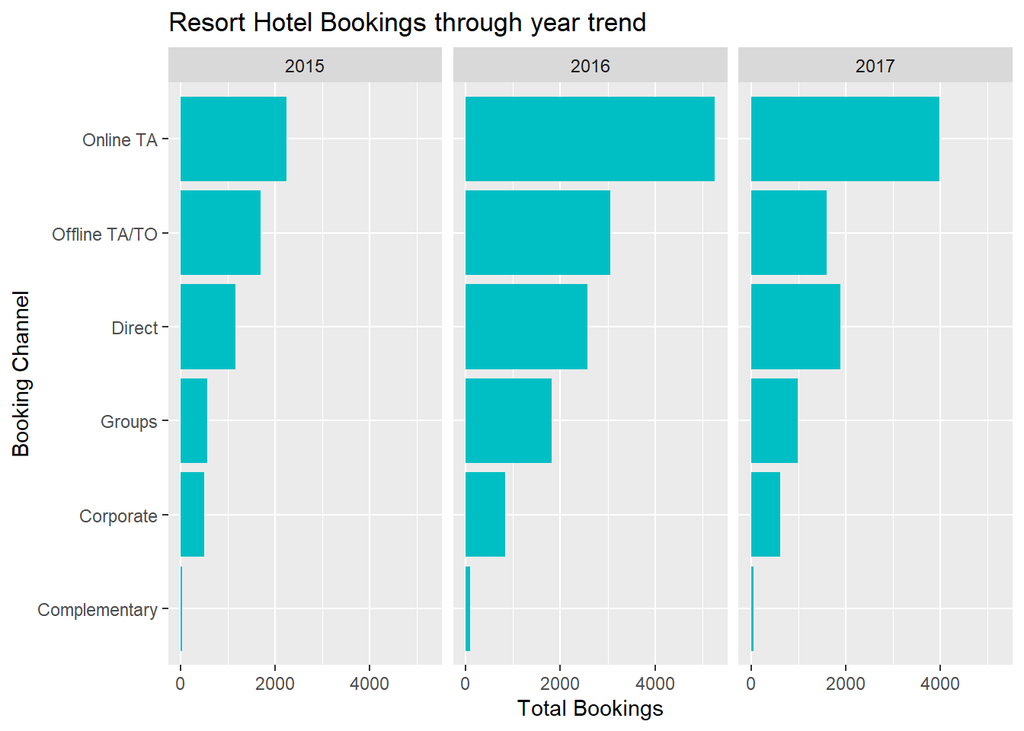

```r
ggplot(data = hotel_mkseg[hotel_mkseg$hotel == "Resort Hotel",], aes(x = reorder(market_segment, bookings), y = bookings)) +
  geom_bar(stat = "identity", fill = "#00BFC4") +
  coord_flip() +
  scale_y_continuous(name="Total Bookings") +
  scale_x_discrete(name="Booking Channel") +
  ggtitle("Resort Hotel Bookings through year trend") +
  facet_wrap(~arrival_date_year)
```

#### 4.5.2 Analysis and Trends to Answer Key Questions

Based on the above data exploration we now check our data for trends to validate our proposed hypothesis to devise strategies to hotel bookings.

##### Hypothesis 1

**The bookings made through travel agencies tend to not get cancelled**

In order to test the validity of the first hypothesis proposed, we will filter the bookings made through travel agencies from the market_segment and plot these booking against the cancellation flag is_canceled. This plot will help us accept or reject the hypothesis.

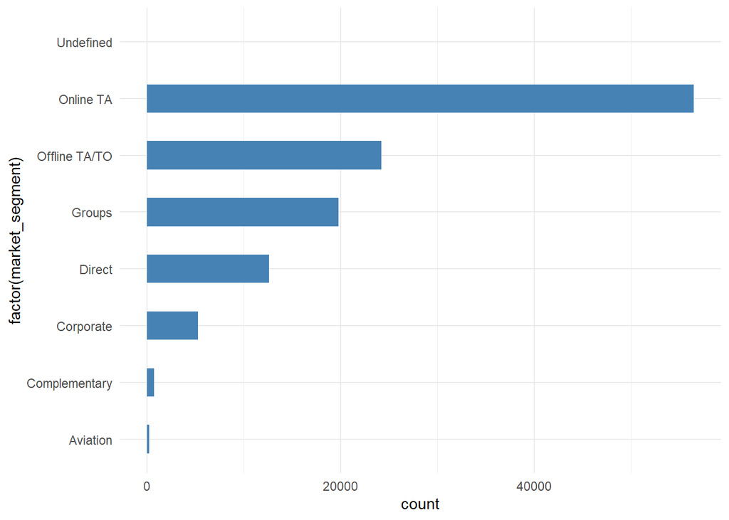

```r
library(ggplot2)
hotels$is_canceled <- as.character(hotels$is_canceled)

TA <- ggplot(data=hotels, aes(x=factor(market_segment), fill=is_canceled)) +
geom_bar(stat="count", position=position_dodge()) +
    coord_flip()


ms<- ggplot(data=hotels, aes(x=factor(market_segment))) +
  geom_bar(stat="count", width = 0.5, fill="steelblue")+
  theme_minimal() +
  coord_flip()

ms
```

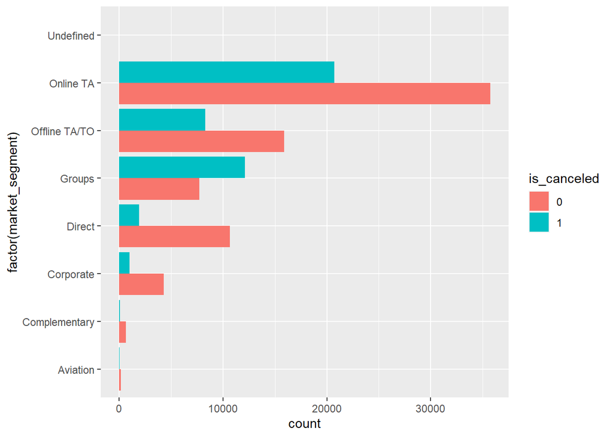

```r
TA
```

Here we see that comparing the number of cancellations across different channels, maximum cancellations occur for bookings made by online travel agent.

##### Hypothesis 2

**People with more family members tend to make bookings with travel agencies**

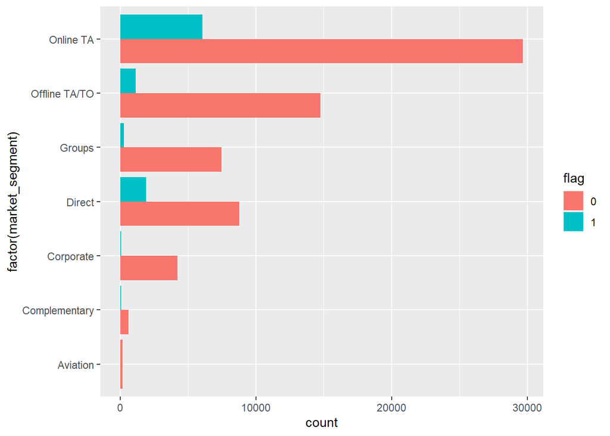

```r
library(ggplot2)
library(dplyr)
hotels$members = hotels$adults + hotels$children + hotels$babies
hotels_not_cancelled <- hotels %>% filter(is_canceled==0)
hotels_not_cancelled <- hotels_not_cancelled %>%
  mutate(flag = if_else(members > 2, 1,0))

hotels_not_cancelled$flag <- as.character(hotels_not_cancelled$flag)

ggplot(data=hotels_not_cancelled, aes(x=factor(market_segment), fill=flag)) +
geom_bar(stat="count", position=position_dodge()) +
    coord_flip()
```

Here first we filtered for the bookings which were not cancelled. Among those, we created a flag where, if the members > 2 for a booking, flag is 1, 2 or less, flag is 0. We see that booking with more people are done mostly through online travel agent followed by direct bookings. Which proves our hypothesis to be true.